[figure not shown]

# LIJUN LIN

27 de Noviembre de 2019

https://github.com/LINLJN/Proyecto-Final.git

# Exprexiones regulares

## ¿Que son las expresiones regulares?

En cómputo teórico y teoría de lenguajes formales una expresión regular, o expresión racional, es una secuencia de caracteres que conforma un patrón de búsqueda. También son conocidas como regex o regexp, por su contracción de las palabras inglesas regular expression. Son principalmente utilizadas para la búsqueda de patrones de cadenas de caracteres u operaciones de sustituciones.

En informática, las expresiones regulares proporcionan una manera muy flexible de buscar o reconocer cadenas de texto

## Recursos sobre expresiones regulares

En la busqueda de las expresiones regulares, nos encontramos con la web [RPubs](http://rpubs.com/ydmarinb/429756), es una de las principales páginas webs de consulta del Rstudio, y sin duda una de las mejores y completas, ya que en ella podemos encontrar soluciones para nuestros problemas o manuales. Volviendo al tema, en la pagina citada anteriormete, podemos encontrar con la definición y la teoría del mismo, y lo más importante consta de un manual de todas las expresiones y sus finciones. También hay un apartado de *Implementación en R*, donde explica como se detecta un patron, localización de un patron y otras funciones.

Otra de las paginas es de [Microsoft](https://docs.microsoft.com/es-es/dotnet/standard/base-types/regular-expression-language-quick-reference), esta página empieza con un índice en el encabezado y seguido de una breve definición como introducción, a diferencia de anterior [RPubs](http://rpubs.com/ydmarinb/429756), nos da la opción de descargar el contenido de la página en formato Word o en PDF, también como la página de RPubs tiene un manual, y en este caso se trata de un manual mucho más detallado y más técnico, consta también de una explicación de cada una de las categorias de expresiones, por ejemplo: *Un cuantificador especifica cuántas instancias del elemento anterior…*. Hay que mencionar que es mucho más extensa como ejemplos de expresiones regulares y explicaciones de otras muchas funciones.

## Opinion personal

En general tanto [RPubs](http://rpubs.com/ydmarinb/429756) como [Microsoft](https://docs.microsoft.com/es-es/dotnet/standard/base-types/regular-expression-language-quick-reference), las dos páginas son excepcionales, ya que la información es clara y ordenada. Pero desde un punto más crítico, recomendaría la de [Microsoft](https://docs.microsoft.com/es-es/dotnet/standard/base-types/regular-expression-language-quick-reference), ya que en comparación es mucho más completo, abarca desde Escapes de carácter hasta Construcciones misceláneas. En cambio la otra solo algúnas funciones básicas

# Markdown

## ¿Que es Markdown?

Markdown es un lenguaje de marcado ligero creado por John Gruber que trata de conseguir la máxima legibilidad y facilidad de publicación tanto en su forma de entrada como de salida, inspirándose en muchas convenciones existentes para marcar mensajes de correo electrónico usando texto plano. Se distribuye bajo licencia BSD y se distribuye como plugin (o al menos está disponible) en diferentes sistemas de gestión de contenidos (CMS). Markdown convierte el texto marcado en documentos XHTML utilizando html2text creado por Aaron Swartz. Markdown fue implementado originariamente en Perl por Gruber, pero desde entonces ha sido traducido a multitud de lenguajes de programación, incluyendo PHP, Python, Ruby, Java y Common Lisp.

## Recursos sobre Markdown

En esta ocasión hablaremos sobre dos páginas que contengan manuales para el el uso del Markdown y sus expresiones, en primer lugar hablaremos sobre la página [Joedicastro](https://joedicastro.com/pages/markdown.html), es una página de guía para recordar todas las posibilidades que el ofrece tanto de Markdown como Pygments, para editar y formatear texto. Se trata de una página muy sencilla, con sencilla quiero decir que para acceder a la información es basntante fácil, ya que no necesitamos navegar dentro de su web. A la hora de usar la guía resulta bastante intuitiva, ya que se han molestado en poner en el cabezado de la tabla *Tecleas -> Obtines*, siendo muy visual.

La otra página que mencionaremos es [Markdown](https://markdown.es/sintaxis-markdown/), se trata de una página de tutoriales de Markdown, bastante similar a la página anteriormente nombrada, pero hay que destacar que en este caso tenemos videos explicativos [Markdown en 5 min](https://www.youtube.com/watch?time_continue=1&v=y6XdzBNC0_0&feature=emb_logo), pero en cambio la página tiene una desventaja, es que tiene bastantes anuncios entre guía y guía. En este caso también nos lo expliaca con ejemplos, facilitando nuestro aprendizaje.

## Opinion personal

Desde mi punto de vista, la página [Joedicastro](https://joedicastro.com/pages/markdown.html) ha resultado ganadora, por el motivo de que la informacion presentada es mucho más clara y sencilla de entender, tambien hay que destacar que el tamaño de la letra es más grande y es más fácil de leer. Puntos negativos de la página [Markdown](https://markdown.es/sintaxis-markdown/), excesivos anuncios, letras muy pequeñas, poco intuitivo.

# Evolución de la población Española

Un total de 46.934.632 personas viven en España en el semestre 1 de 2019, lo que supone un aumento de 201.592 personas respecto al periodo anterior y una variación de 0,59% en comparación con el mismo periodo del año pasado, según las últimas cifras publicadas por el Instituto Nacional de Estadística (INE).

Población residente en España

| Indicador | Valor | Variación semestral |
| --- | --- | --- |
| Población total | 46.934.632 | 0,44 |
| Hombres | 23.007.862 | 0,42 |
| Mujeres | 23.926.770 | 0,46 |
| Extranjeros | 4.848.516 | 4,03 |

Note:  
Fuente INEI.  
<sup>1</sup> Datos de 1 de enero de 2019 (Provisional)

Se publica una serie poblacional desde el año 1971 que se obtiene de las estimaciones intercensales de la población, para el período 1971-2012, y de la propia operación Cifras de población, a partir de 2012.

Los datos así obtenidos se emplean como cifras poblacionales de referencia en todas las operaciones estadísticasque el INE realiza (encuestas, Contabilidad Nacional, indicadores, etc.) y se transmiten a nivel internacional como datos oficiales de la población de España a todos los efectos.

[interactive chart not shown]

### ¿Existirá alguna relación entre el crecimiento de la población y el crecimiento económico?

En la práctica podría parecer que sí. Muchos estudios indican que la relación entre el crecimiento demográfico y el PIB de una región es incierta. El PIB o producto interno bruto es un indicador importante del desempeño económico de un país. Esta medida representa el valor final de los bienes y servicios producidos dentro de los límites geográficos de un país durante un período de tiempo determinado. Por otra parte, la expresión crecimiento demográfico hace referencia al cambio poblacional de una determinada región. El tamaño y la densidad de la población se relacionaron positivamente con el crecimiento del PIB.

## Gráfica de crecimiento de la población

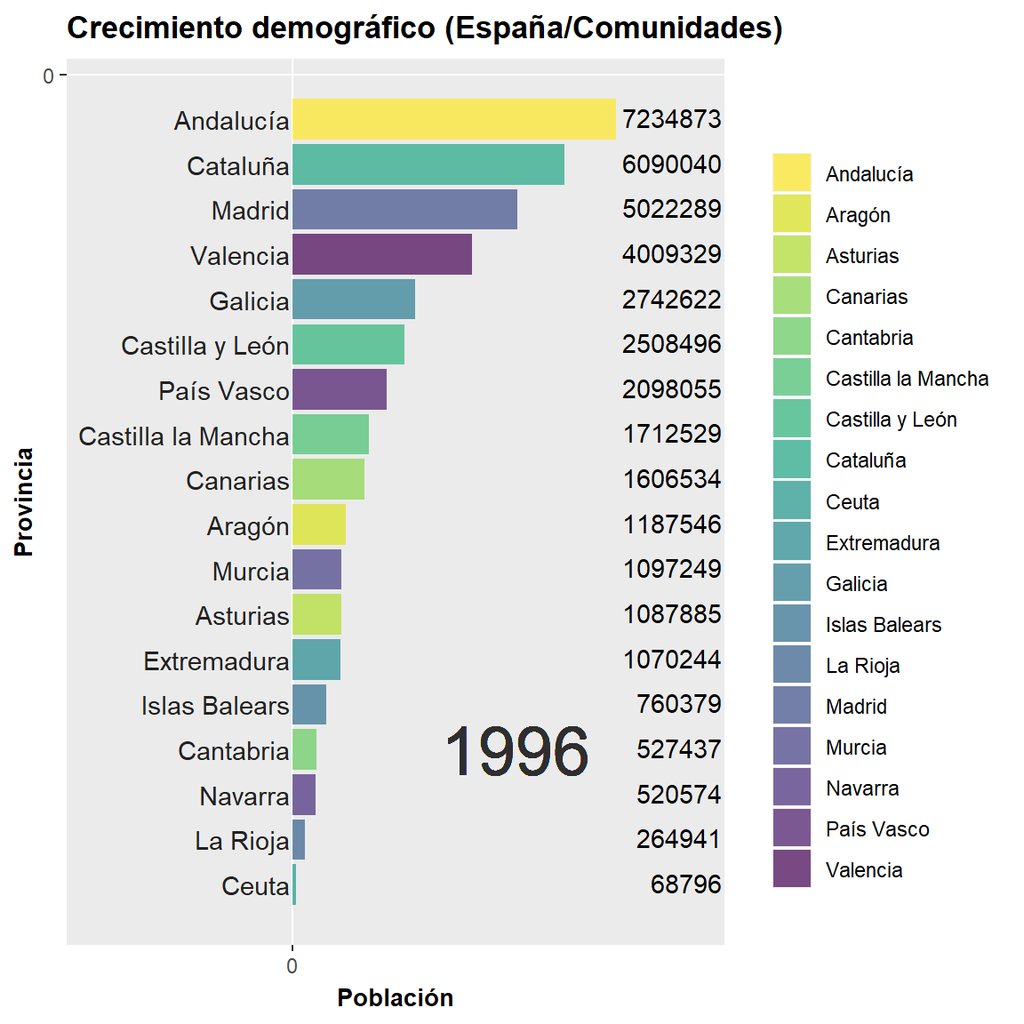

Los datos estan resumidas por comunidades autónomas, como verás no existen datos del año 1997, ya que en ese año no se revisó el padrón para ese año.